# Staying or Straying: The Effects of Relationship Inititation and Attachment Style on Commitment

- Show All Code
- Hide All Code
- View Source

PSY 120L Reproducible Analysis Report

Author

Samantha Mazariego Chinchilla

Published

June 6, 2026

## Introduction

This document represents the initial stages of a data analysis workflow using the provided data set obtained through our studies. The purpose of this document is to organize the analysis into a clear and reproducible structure, including data loading, inspection, and preparation steps. The data set used in this analysis will be in introduced and examined to understand its structure before proceeding to further analysis.

```r
knitr::opts_chunk$set(
  echo = TRUE,
  message = FALSE,
  warning = FALSE,
  fig.align = "center"
)

options(stringsAsFactors = FALSE)
```

## Setup and Software Environment

This section loads the software packages required to conduct the analysis. With these packages, we will be able to have the tools needed to import data, clean, and analyze the data. These packages must be loaded before any steps are ran.

**Load Packages**

```r
library(tidyverse)
library(psych)
library(afex)
library(emmeans)
```

## Data Source

In this section, we will import the raw data obtained through out survey sent out to use in our analysis and load it into the R environment. The main goal in this section is to make the data available for further processing in the future steps.

### Import Dataset

```r
study_raw <- read_csv("data/staying_straying_data.csv")
```

### Check Imported Dataset

```r
dim(study_raw)
```

```
[1] 57 27
```

```r
names(study_raw)
```

```
 [1] "ResponseId"          "DistributionChannel" "Consent"
 [4] "Commit_1"            "Commit_2"            "Commit_3"
 [7] "Commit_4"            "Commit_5"            "Commit_6"
[10] "Commit_7"            "Commit_8"            "ECRS_1"
[13] "ECRS_2"              "ECRS_3"              "ECRS_4"
[16] "ECRS_5"              "ECRS_6"              "ECRS_7"
[19] "ECRS_8"              "ECRS_9"              "ECRS_10"
[22] "ECRS_11"             "ECRS_12"             "zodiac"
[25] "age"                 "gender"              "condition"
```

```r
head(study_raw)
```

```
# A tibble: 6 × 27
  ResponseId     DistributionChannel Consent Commit_1 Commit_2 Commit_3 Commit_4
  <chr>          <chr>                 <dbl>    <dbl>    <dbl>    <dbl>    <dbl>
1 R_33jar6hZfXT… email                     1        7        8        6        3
2 R_3YTqJ9eK2Nl… email                     1        9        9        9        1
3 R_5Gkbu0b4OR5… email                     1        9        9        5        3
4 R_7E0Dy5fon0s… email                     1        9        9        8        1
5 R_5EEjq5YU90w… email                     1        6        6        6        1
6 R_1KVKyaSSdhL… email                     1        6        7        7        2
# ℹ 20 more variables: Commit_5 <dbl>, Commit_6 <dbl>, Commit_7 <dbl>,
#   Commit_8 <dbl>, ECRS_1 <dbl>, ECRS_2 <dbl>, ECRS_3 <dbl>, ECRS_4 <dbl>,
#   ECRS_5 <dbl>, ECRS_6 <dbl>, ECRS_7 <dbl>, ECRS_8 <dbl>, ECRS_9 <dbl>,
#   ECRS_10 <dbl>, ECRS_11 <dbl>, ECRS_12 <dbl>, zodiac <dbl>, age <dbl>,
#   gender <dbl>, condition <dbl>
```

### Create Analysis Dataset

```r
study_vars <- c(
  "condition", "zodiac", "age", "gender",

  "Commit_1", "Commit_2", "Commit_3", "Commit_4",
  "Commit_5", "Commit_6", "Commit_7", "Commit_8",
  "ECRS_1", "ECRS_2", "ECRS_3", "ECRS_4", "ECRS_5", "ECRS_6",
  "ECRS_7", "ECRS_8", "ECRS_9", "ECRS_10", "ECRS_11", "ECRS_12"

)



study_data <- study_raw %>%
  select(all_of(study_vars)) %>%
  mutate(
    across(everything(), as.numeric)
  )
```

### Check Analysis Dataset

```r
length(study_vars)
```

```
[1] 24
```

```r
dim(study_data)
```

```
[1] 57 24
```

```r
names(study_data)
```

```
 [1] "condition" "zodiac"    "age"       "gender"    "Commit_1"  "Commit_2"
 [7] "Commit_3"  "Commit_4"  "Commit_5"  "Commit_6"  "Commit_7"  "Commit_8"
[13] "ECRS_1"    "ECRS_2"    "ECRS_3"    "ECRS_4"    "ECRS_5"    "ECRS_6"
[19] "ECRS_7"    "ECRS_8"    "ECRS_9"    "ECRS_10"   "ECRS_11"   "ECRS_12"
```

*This confims the total number of variables in the list.*

## Variable Preparation

*Only variables defined in our Master key will be analyzed here.*

### Prepare Participant ID and Experimental Condition

```r
study_data <- study_data %>%
  mutate(
    id = row_number(),
    condition = factor(
      condition,
      levels = c(0, 1),
      labels = c("Online", "In Person")
    )
  )
```

In this code, we are able to add an ID number for each participants. It also changes the variable, in-person & online, into labels instead of numbers. This will make it easier to read and understand.

### Check Experimental Condition Coding

```r
study_data %>%
  count(condition) %>%
  knitr::kable(
    col.names = c("Condition", "n")
  )
```

| Condition | n |
| --- | --- |
| Online | 28 |
| In Person | 25 |
| NA | 4 |

The code checks for how man participants are in each condition.

### Check Prepared Analysis Dataset

```r
dim(study_data)
```

```
[1] 57 25
```

```r
names(study_data)
```

```
 [1] "condition" "zodiac"    "age"       "gender"    "Commit_1"  "Commit_2"
 [7] "Commit_3"  "Commit_4"  "Commit_5"  "Commit_6"  "Commit_7"  "Commit_8"
[13] "ECRS_1"    "ECRS_2"    "ECRS_3"    "ECRS_4"    "ECRS_5"    "ECRS_6"
[19] "ECRS_7"    "ECRS_8"    "ECRS_9"    "ECRS_10"   "ECRS_11"   "ECRS_12"
[25] "id"
```

### Reverse-Code Scale Items

This lets us reverse-code selected survey questions so that all responses are scored in the same direction. The higher value in the ECRS scale will now match with the original trait being measured.

```r
study_data <- study_data %>%
  mutate(
    ECRS_1r = 8 - ECRS_1,
    ECRS_5r = 8 - ECRS_5,
    ECRS_8r = 8 - ECRS_8,
    ECRS_9r = 8 - ECRS_9,


    Commit_4r = 10 - Commit_4,
    Commit_5r = 10 - Commit_5,
    Commit_8r = 10 - Commit_8

  )
```

### Check Reverse Coding

```r
study_data %>%
  select(ECRS_1, ECRS_1r, Commit_4, Commit_4r) %>%
  head(10) %>%
  knitr::kable()
```

| ECRS_1 | ECRS_1r | Commit_4 | Commit_4r |
| --- | --- | --- | --- |
| 6 | 2 | 3 | 7 |
| 7 | 1 | 1 | 9 |
| 5 | 3 | 3 | 7 |
| 7 | 1 | 1 | 9 |
| 7 | 1 | 1 | 9 |
| 6 | 2 | 2 | 8 |
| 6 | 2 | 2 | 8 |
| 7 | 1 | 1 | 9 |
| 5 | 3 | 2 | 8 |
| 7 | 1 | 2 | 8 |

### Create Scale Scores

This groups the survey question into different scales, based on their attachment insecurity, anxiety, or avoidance.

```r
ECRS_items <- c(
  "ECRS_1r", "ECRS_2", "ECRS_3", "ECRS_4", "ECRS_5r", "ECRS_6",
  "ECRS_7", "ECRS_8r", "ECRS_9r", "ECRS_10", "ECRS_11", "ECRS_12"
)

ECRS_anxiety_items <- c(
  "ECRS_2", "ECRS_4", "ECRS_6", "ECRS_8r", "ECRS_10", "ECRS_12"
)

ECRS_avoidance_items <- c(
  "ECRS_1r", "ECRS_3", "ECRS_5r", "ECRS_7", "ECRS_9r", "ECRS_11"
)

commitment_items <- c(
  "Commit_1", "Commit_2", "Commit_3", "Commit_4r",
  "Commit_5r", "Commit_6", "Commit_7", "Commit_8r"
)

study_data <- study_data %>%
  mutate(
    ECRS_scale = rowMeans(across(all_of(ECRS_items)), na.rm = TRUE),
    ECRS_anxiety = rowMeans(across(all_of(ECRS_anxiety_items)), na.rm = TRUE),
    ECRS_avoidance = rowMeans(across(all_of(ECRS_avoidance_items)), na.rm = TRUE),
    commitment = rowMeans(across(all_of(commitment_items)), na.rm = TRUE)
  )
```

### Check Scale Scores

```r
study_data %>%
  select(
    ECRS_scale,
    ECRS_anxiety,
    ECRS_avoidance,
    commitment
  ) %>%
  summary()
```

```
   ECRS_scale     ECRS_anxiety   ECRS_avoidance    commitment
 Min.   :1.500   Min.   :1.667   Min.   :1.000   Min.   :4.000
 1st Qu.:2.833   1st Qu.:3.333   1st Qu.:2.000   1st Qu.:6.000
 Median :3.417   Median :4.000   Median :2.583   Median :6.875
 Mean   :3.330   Mean   :4.041   Mean   :2.590   Mean   :6.765
 3rd Qu.:3.750   3rd Qu.:4.667   3rd Qu.:3.167   3rd Qu.:7.625
 Max.   :4.917   Max.   :5.833   Max.   :4.833   Max.   :9.000
 NA's   :8       NA's   :8       NA's   :9       NA's   :8
```

```r
study_data %>%
  summarise(
    ECRS_scale_missing = mean(is.na(ECRS_scale)),
    ECRS_anxiety_missing = mean(is.na(ECRS_anxiety)),
    ECRS_avoidance_missing = mean(is.na(ECRS_avoidance)),
    commitment_missing = mean(is.na(commitment))
  ) %>%
  knitr::kable()
```

| ECRS_scale_missing | ECRS_anxiety_missing | ECRS_avoidance_missing | commitment_missing |
| --- | --- | --- | --- |
| 0.1403509 | 0.1403509 | 0.1578947 | 0.1403509 |

*This is making sure it worked, we see the calculation for the ECRS scale, and it divided into anxiety, avoidance, and their commitment level.*

### Create Attachment Groups

An attachment group is created by calculating the median for attachment anxiety, avoidance, and insecurity. Participants are divided into two groups depending if they fall below or above the median scores.

```r
ECRS_median <- median(study_data$ECRS_scale, na.rm = TRUE)
ECRS_anxiety_median <- median(study_data$ECRS_anxiety, na.rm = TRUE)
ECRS_avoidance_median <- median(study_data$ECRS_avoidance, na.rm = TRUE)

study_data <- study_data %>%
  mutate(
    ECRS_msplit = if_else(ECRS_scale <= ECRS_median, "Low", "High"),
    ECRS_msplit = factor(ECRS_msplit, levels = c("Low", "High")),

    ECRS_anxiety_msplit = if_else(ECRS_anxiety <= ECRS_anxiety_median, "Low", "High"),
    ECRS_anxiety_msplit = factor(ECRS_anxiety_msplit, levels = c("Low", "High")),

    ECRS_avoidance_msplit = if_else(ECRS_avoidance <= ECRS_avoidance_median, "Low", "High"),
    ECRS_avoidance_msplit = factor(ECRS_avoidance_msplit, levels = c("Low", "High"))
  )

ECRS_median
```

```
[1] 3.416667
```

```r
ECRS_anxiety_median
```

```
[1] 4
```

```r
ECRS_avoidance_median
```

```
[1] 2.583333
```

```r
study_data %>%
  count(ECRS_msplit) %>%
  knitr::kable()
```

| ECRS_msplit | n |
| --- | --- |
| Low | 27 |
| High | 22 |
| NA | 8 |

```r
study_data %>%
  count(ECRS_anxiety_msplit) %>%
  knitr::kable()
```

| ECRS_anxiety_msplit | n |
| --- | --- |
| Low | 26 |
| High | 23 |
| NA | 8 |

```r
study_data %>%
  count(ECRS_avoidance_msplit) %>%
  knitr::kable()
```

| ECRS_avoidance_msplit | n |
| --- | --- |
| Low | 24 |
| High | 24 |
| NA | 9 |

This shows us that 27 participants are below the median score and 22 are above the median score.

### Check Scale Reliability

This section checks the reliability of each rating by only selecting the item chose in the code.

```r
ECRS_item_df <- study_data %>%
  select(all_of(ECRS_items))

ECRS_anxiety_item_df <- study_data %>%
  select(all_of(ECRS_anxiety_items))

ECRS_avoidance_item_df <- study_data %>%
  select(all_of(ECRS_avoidance_items))

commitment_item_df <- study_data %>%
  select(all_of(commitment_items))

ECRS_alpha <- psych::alpha(ECRS_item_df)
```

```
Some items ( ECRS_2 ECRS_8r ECRS_10 ECRS_12 ) were negatively correlated with the first principal component and
probably should be reversed.
To do this, run the function again with the 'check.keys=TRUE' option
```

```r
ECRS_omega <- psych::omega(ECRS_item_df, plot = FALSE)

ECRS_anxiety_alpha <- psych::alpha(ECRS_anxiety_item_df)
ECRS_anxiety_omega <- psych::omega(ECRS_anxiety_item_df, plot = FALSE)

ECRS_avoidance_alpha <- psych::alpha(ECRS_avoidance_item_df)
ECRS_avoidance_omega <- psych::omega(ECRS_avoidance_item_df, plot = FALSE)

commitment_alpha <- psych::alpha(commitment_item_df)
commitment_omega <- psych::omega(commitment_item_df, plot = FALSE)

tibble(
  scale = c(
    "ECR-S Attachment Insecurity",
    "ECR-S Attachment Anxiety",
    "ECR-S Attachment Avoidance",
    "Commitment"
  ),
  alpha = c(
    ECRS_alpha$total$raw_alpha,
    ECRS_anxiety_alpha$total$raw_alpha,
    ECRS_avoidance_alpha$total$raw_alpha,
    commitment_alpha$total$raw_alpha
  ),
  omega = c(
    ECRS_omega$omega.tot,
    ECRS_anxiety_omega$omega.tot,
    ECRS_avoidance_omega$omega.tot,
    commitment_omega$omega.tot
  )
) %>%
  knitr::kable(digits = 2)
```

| scale | alpha | omega |
| --- | --- | --- |
| ECR-S Attachment Insecurity | 0.63 | 0.81 |
| ECR-S Attachment Anxiety | 0.59 | 0.62 |
| ECR-S Attachment Avoidance | 0.78 | 0.89 |
| Commitment | 0.77 | 0.89 |

*We see the calculated alpha and omega, using this we can see how much the item was measured. A higher value usually suggest that there is a correlation.*

## Descriptive Statistics

Here will calculate the mean, median. sd, etc. for attachment insecurity, attachment anxiety, attachment avoidance, and commitment.

### Scale Score Descriptives

```r
study_data %>%
  select(
    ECRS_scale,
    ECRS_anxiety,
    ECRS_avoidance,
    commitment
  ) %>%
  psych::describe() %>%
  knitr::kable(digits = 2)
```

|  | vars | n | mean | sd | median | trimmed | mad | min | max | range | skew | kurtosis | se |
| --- | --- | --- | --- | --- | --- | --- | --- | --- | --- | --- | --- | --- | --- |
| ECRS_scale | 1 | 49 | 3.33 | 0.67 | 3.42 | 3.36 | 0.62 | 1.50 | 4.92 | 3.42 | -0.47 | 0.50 | 0.10 |
| ECRS_anxiety | 2 | 49 | 4.04 | 0.93 | 4.00 | 4.06 | 0.99 | 1.67 | 5.83 | 4.17 | -0.21 | -0.18 | 0.13 |
| ECRS_avoidance | 3 | 48 | 2.59 | 0.94 | 2.58 | 2.55 | 0.86 | 1.00 | 4.83 | 3.83 | 0.39 | -0.20 | 0.14 |
| commitment | 4 | 49 | 6.77 | 1.23 | 6.88 | 6.77 | 1.11 | 4.00 | 9.00 | 5.00 | -0.15 | -0.54 | 0.18 |

```r
study_data %>%
  summarise(
    mean_age = mean(age, na.rm = TRUE),
    sd_age = sd(age, na.rm = TRUE),
    min_age = min(age, na.rm = TRUE),
    max_age = max(age, na.rm = TRUE)
  ) %>%
  knitr::kable(
    digits = 2,
    col.names = c("Mean", "SD", "Minimum", "Maximum"),
    caption = "Sample Age: Mean, Standard Deviation, and Range"
  )
```

Sample Age: Mean, Standard Deviation, and Range

| Mean | SD | Minimum | Maximum |
| --- | --- | --- | --- |
| 21.69 | 1.61 | 19 | 28 |

```r
study_data %>%
  count(gender) %>%
  arrange(gender) %>%
  mutate(percent = round(100 * n / sum(n), 1)) %>%
  knitr::kable(
    col.names = c("Gender", "n", "Percent"),
    caption = "Sample Composition by Gender"
  )
```

Sample Composition by Gender

| Gender | n | Percent |
| --- | --- | --- |
| 1 | 5 | 8.8 |
| 2 | 43 | 75.4 |
| NA | 9 | 15.8 |

## Correlations Among the DVs

We begin to test the relationship among the dependent variables.

```r
psych::corr.test(
  study_data %>%
    select(
      ECRS_scale,
      ECRS_anxiety,
      ECRS_avoidance,
      commitment
    )
)
```

```
Call:psych::corr.test(x = study_data %>% select(ECRS_scale, ECRS_anxiety,
    ECRS_avoidance, commitment))
Correlation matrix
               ECRS_scale ECRS_anxiety ECRS_avoidance commitment
ECRS_scale           1.00         0.70           0.71      -0.27
ECRS_anxiety         0.70         1.00           0.01       0.04
ECRS_avoidance       0.71         0.01           1.00      -0.40
commitment          -0.27         0.04          -0.40       1.00
Sample Size
               ECRS_scale ECRS_anxiety ECRS_avoidance commitment
ECRS_scale             49           49             48         49
ECRS_anxiety           49           49             48         49
ECRS_avoidance         48           48             48         48
commitment             49           49             48         49
Probability values (Entries above the diagonal are adjusted for multiple tests.)
               ECRS_scale ECRS_anxiety ECRS_avoidance commitment
ECRS_scale           0.00         0.00           0.00       0.17
ECRS_anxiety         0.00         0.00           1.00       1.00
ECRS_avoidance       0.00         0.97           0.00       0.02
commitment           0.06         0.79           0.01       0.00

 To see confidence intervals of the correlations, print with the short=FALSE option
```

## Primary Analyses

The ANOVA test will be used to examine whether relationship results different across attachment styles and conditional variable. It will test for both main effects and interaction effects.

### **Commitment Model (total ECRS split)**

```r
a1_commitment <- afex::aov_ez(
  id = "id",
  dv = "commitment",
  between = c("condition", "ECRS_msplit"),
  data = study_data
)

a1_commitment
```

```
Anova Table (Type 3 tests)

Response: commitment
                 Effect    df  MSE    F  ges p.value
1             condition 1, 45 1.50 0.30 .007    .588
2           ECRS_msplit 1, 45 1.50 1.76 .038    .192
3 condition:ECRS_msplit 1, 45 1.50 0.73 .016    .397
---
Signif. codes:  0 '***' 0.001 '**' 0.01 '*' 0.05 '+' 0.1 ' ' 1
```

```r
emmeans(a1_commitment, ~ condition)
```

```
 condition emmean    SE df lower.CL upper.CL
 Online      6.82 0.234 45     6.34     7.29
 In Person   6.62 0.268 45     6.08     7.16

Results are averaged over the levels of: ECRS_msplit
Confidence level used: 0.95
```

```r
emmeans(a1_commitment, ~ ECRS_msplit)
```

```
 ECRS_msplit emmean    SE df lower.CL upper.CL
 Low           6.95 0.240 45     6.47     7.44
 High          6.48 0.263 45     5.95     7.01

Results are averaged over the levels of: condition
Confidence level used: 0.95
```

```r
emmeans(a1_commitment, ~ condition * ECRS_msplit)
```

```
 condition ECRS_msplit emmean    SE df lower.CL upper.CL
 Online    Low           7.20 0.307 45     6.59     7.82
 In Person Low           6.70 0.370 45     5.96     7.45
 Online    High          6.43 0.354 45     5.71     7.14
 In Person High          6.54 0.388 45     5.76     7.32

Confidence level used: 0.95
```

### **Commitment** Model (ECRS Anxiety)

```r
a2_commitment_anxiety <- afex::aov_ez(
  id = "id",
  dv = "commitment",
  between = c("condition", "ECRS_anxiety_msplit"),
  data = study_data
)


a2_commitment_anxiety
```

```
Anova Table (Type 3 tests)

Response: commitment
                         Effect    df  MSE    F   ges p.value
1                     condition 1, 45 1.59 0.52  .011    .474
2           ECRS_anxiety_msplit 1, 45 1.59 0.04 <.001    .837
3 condition:ECRS_anxiety_msplit 1, 45 1.59 0.27  .006    .603
---
Signif. codes:  0 '***' 0.001 '**' 0.01 '*' 0.05 '+' 0.1 ' ' 1
```

```r
emmeans(a2_commitment_anxiety, ~ condition)
```

```
 condition emmean    SE df lower.CL upper.CL
 Online      6.87 0.238 45     6.39     7.35
 In Person   6.61 0.278 45     6.05     7.17

Results are averaged over the levels of: ECRS_anxiety_msplit
Confidence level used: 0.95
```

```r
emmeans(a2_commitment_anxiety, ~ ECRS_anxiety_msplit)
```

```
 ECRS_anxiety_msplit emmean    SE df lower.CL upper.CL
 Low                   6.78 0.248 45     6.28     7.28
 High                  6.70 0.269 45     6.16     7.24

Results are averaged over the levels of: condition
Confidence level used: 0.95
```

```r
emmeans(a2_commitment_anxiety, ~ condition * ECRS_anxiety_msplit)
```

```
 condition ECRS_anxiety_msplit emmean    SE df lower.CL upper.CL
 Online    Low                   6.81 0.337 45     6.13     7.49
 In Person Low                   6.74 0.364 45     6.01     7.47
 Online    High                  6.93 0.337 45     6.25     7.61
 In Person High                  6.47 0.420 45     5.63     7.32

Confidence level used: 0.95
```

*The output is the estimated marginal mean showing the average commitment scores. Participants in the Online condition only reported a slightly higher commitment score than those in person.*

### **Commitment** Model (ECRS Avoidance)

```r
a3_commitment_avoidance <- afex::aov_ez(
  id = "id",
  dv = "commitment",
  between = c("condition", "ECRS_avoidance_msplit"),
  data = study_data
)


a3_commitment_avoidance
```

```
Anova Table (Type 3 tests)

Response: commitment
                           Effect    df  MSE      F   ges p.value
1                       condition 1, 44 1.40   0.59  .013    .445
2           ECRS_avoidance_msplit 1, 44 1.40 5.58 *  .112    .023
3 condition:ECRS_avoidance_msplit 1, 44 1.40   0.04 <.001    .845
---
Signif. codes:  0 '***' 0.001 '**' 0.01 '*' 0.05 '+' 0.1 ' ' 1
```

```r
emmeans(a3_commitment_avoidance, ~ condition)
```

```
 condition emmean    SE df lower.CL upper.CL
 Online      6.91 0.228 44     6.45     7.37
 In Person   6.65 0.259 44     6.12     7.17

Results are averaged over the levels of: ECRS_avoidance_msplit
Confidence level used: 0.95
```

```r
emmeans(a3_commitment_avoidance, ~ ECRS_avoidance_msplit)
```

```
 ECRS_avoidance_msplit emmean    SE df lower.CL upper.CL
 Low                     7.19 0.245 44     6.69     7.68
 High                    6.37 0.243 44     5.88     6.86

Results are averaged over the levels of: condition
Confidence level used: 0.95
```

```r
emmeans(a3_commitment_avoidance, ~ condition * ECRS_avoidance_msplit)
```

```
 condition ECRS_avoidance_msplit emmean    SE df lower.CL upper.CL
 Online    Low                     7.29 0.317 44     6.65     7.92
 In Person Low                     7.09 0.375 44     6.33     7.84
 Online    High                    6.54 0.329 44     5.88     7.20
 In Person High                    6.20 0.357 44     5.48     6.92

Confidence level used: 0.95
```

## Figures

These codes will create a bar graph for our variables showing the relationship calculated through our analysis.

### Commitment (total ECRS) Interaction Plot

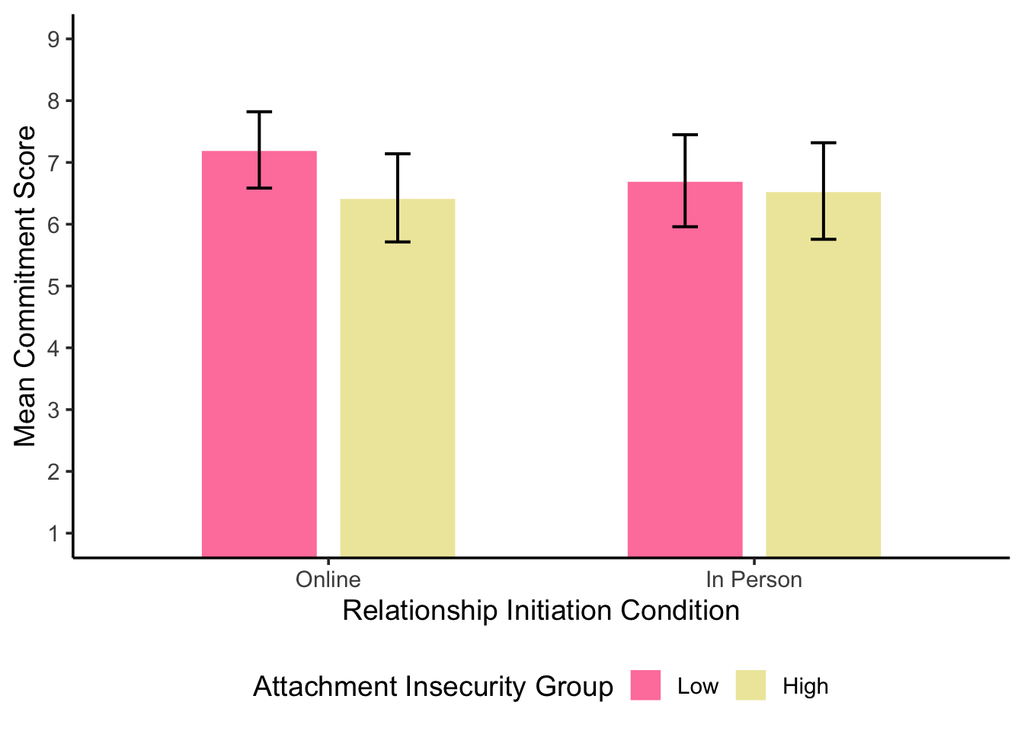

```r
p_total_ecrs_bar <- ggplot(
  as.data.frame(emmeans(a1_commitment, ~ condition * ECRS_msplit)),
  aes(
    x = condition,
    y = emmean,
    fill = ECRS_msplit
  )
) +
  geom_col(
    position = position_dodge(width = 0.65),
    width = 0.55,
    color = "white"
  ) +
  geom_errorbar(
    aes(
      ymin = lower.CL,
      ymax = upper.CL
    ),
    position = position_dodge(width = 0.65),
    width = 0.12,
    linewidth = 0.7
  ) +
  labs(
    x = "Relationship Initiation Condition",
    y = "Mean Commitment Score",
    fill = "Attachment Insecurity Group"
  ) +
  scale_fill_manual(
    values = c(
      "Low" = "palevioletred1", # YOU CAN CHANGE THESE TWO HEX VALUES TO MATCH YOUR POSTER!
      "High" = "palegoldenrod"
    )
  ) +
  scale_y_continuous(
    breaks = seq(1, 9, 1)
  ) +
  coord_cartesian(
    ylim = c(1, 9)
  ) +
  theme_classic(
    base_size = 14
  ) +
  theme(
    legend.position = "bottom"
  )

p_total_ecrs_bar
```

Participants are displayed in this figure on their average commitment score across the online and in-person relationship for those with a high or low attachment insecurity group.

### Commitment (ECRS Anxiety) Interaction Plot

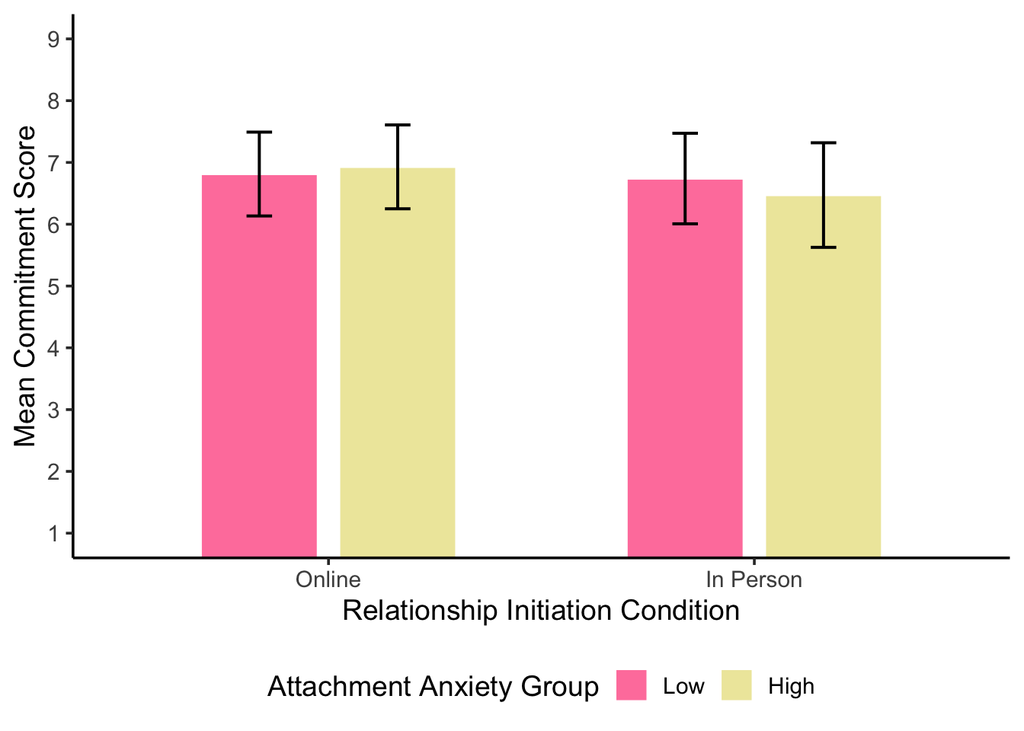

```r
p_anxiety_bar <- ggplot(
  as.data.frame(emmeans(a2_commitment_anxiety, ~ condition * ECRS_anxiety_msplit)),
  aes(
    x = condition,
    y = emmean,
    fill = ECRS_anxiety_msplit
  )
) +
  geom_col(
    position = position_dodge(width = 0.65),
    width = 0.55,
    color = "white"
  ) +
  geom_errorbar(
    aes(
      ymin = lower.CL,
      ymax = upper.CL
    ),
    position = position_dodge(width = 0.65),
    width = 0.12,
    linewidth = 0.7
  ) +
  labs(
    x = "Relationship Initiation Condition",
    y = "Mean Commitment Score",
    fill = "Attachment Anxiety Group"
  ) +
    scale_fill_manual(
    values = c(
            "Low" = "palevioletred1",
      "High" = "palegoldenrod"
    )
  ) +
  scale_y_continuous(
    breaks = seq(1, 9, 1)
  ) +
  coord_cartesian(
    ylim = c(1, 9)
  ) +
  theme_classic(
    base_size = 14
  ) +
  theme(
    legend.position = "bottom"
  )

p_anxiety_bar
```

The figure displays the average commitment scores across the relationship initiation condition for participants with a low and high attachment anxiety group.

### Commitment (ECRS Avoidance) Interaction Plot

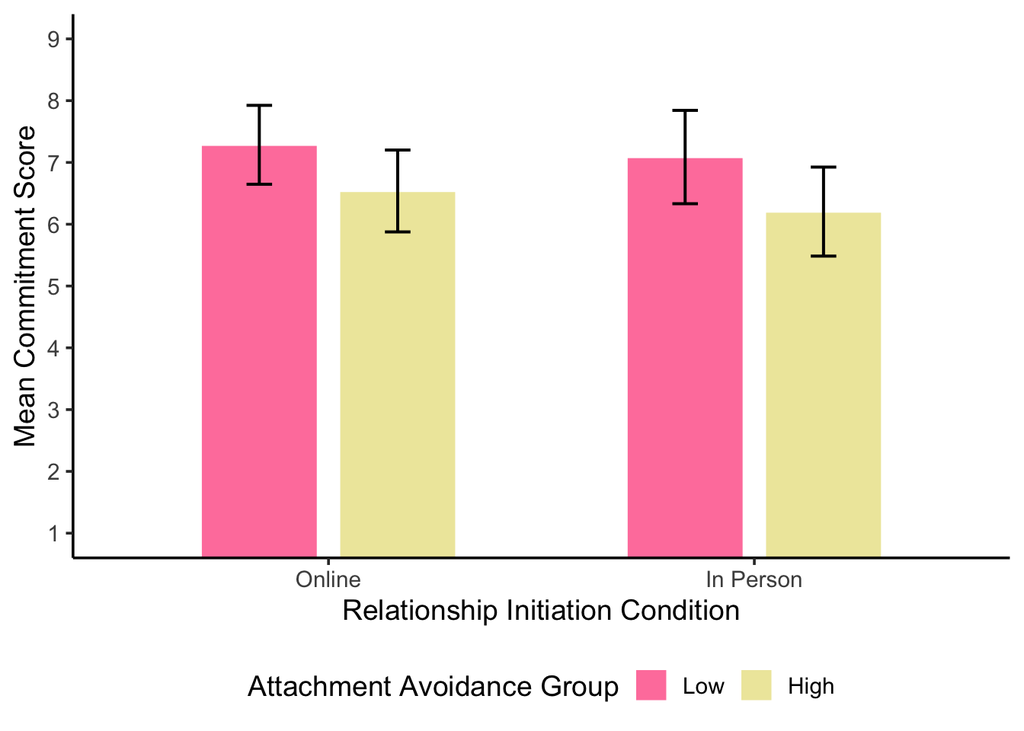

```r
p_avoidance_bar <- ggplot(
  as.data.frame(emmeans(a3_commitment_avoidance, ~ condition * ECRS_avoidance_msplit)),
  aes(
    x = condition,
    y = emmean,
    fill = ECRS_avoidance_msplit
  )
) +
  geom_col(
    position = position_dodge(width = 0.65),
    width = 0.55,
    color = "white"
  ) +
  geom_errorbar(
    aes(
      ymin = lower.CL,
      ymax = upper.CL
    ),
    position = position_dodge(width = 0.65),
    width = 0.12,
    linewidth = 0.7
  ) +
  labs(
    x = "Relationship Initiation Condition",
    y = "Mean Commitment Score",
    fill = "Attachment Avoidance Group"
  ) +
  scale_fill_manual(
    values = c(
        "Low" = "palevioletred1",
      "High" = "palegoldenrod"
    )
  ) +
  scale_y_continuous(
    breaks = seq(1, 9, 1)
  ) +
  coord_cartesian(
    ylim = c(1, 9)
  ) +
  theme_classic(
    base_size = 14
  ) +
  theme(
    legend.position = "bottom"
  )

p_avoidance_bar
```

The figure displays the average commitment scores across the relationship initiation condition for participants with a low and high attachment avoidance group.

### Export Figures

```r
if (!dir.exists("figures")) {
  dir.create("figures")
}

ggsave(
  filename = "figures/total_ecrs_interaction_plot.svg",
  plot = p_total_ecrs_bar,
  width = 7,
  height = 5
)

ggsave(
  filename = "figures/anxiety_interaction_plot.svg",
  plot = p_anxiety_bar,
  width = 7,
  height = 5
)

ggsave(
  filename = "figures/avoidance_interaction_plot.svg",
  plot = p_avoidance_bar,
  width = 7,
  height = 5
)
```